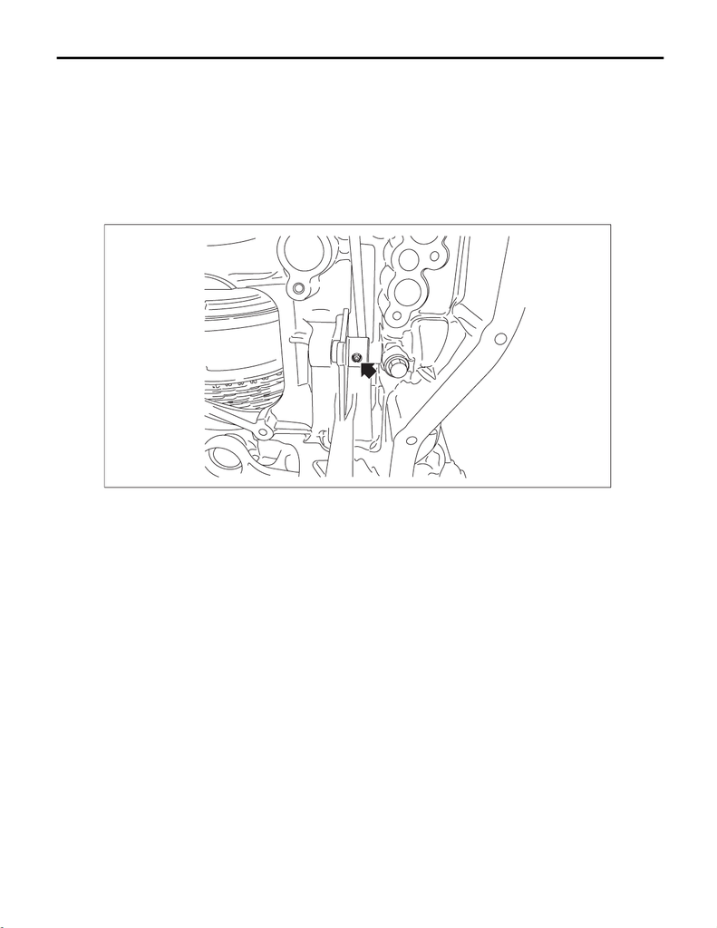

CVT(TR690)-208

Transmission Control Device

CONTINUOUSLY VARIABLE TRANSMISSION

39.Transmission Control Device

A: REMOVAL

Transmission Assembly.>

2) Remove the oil pan and control valve body. <Ref. to CVT(TR690)-112, REMOVAL, Control Valve Body.>

3) Remove the inhibitor switch. <Ref. to CVT(TR690)-95, REMOVAL, Inhibitor Switch.>

4) Remove the spring pin.

NOTE:

Prevent the spring pin from dropping in the transmission using paper towel etc.

AT-05274

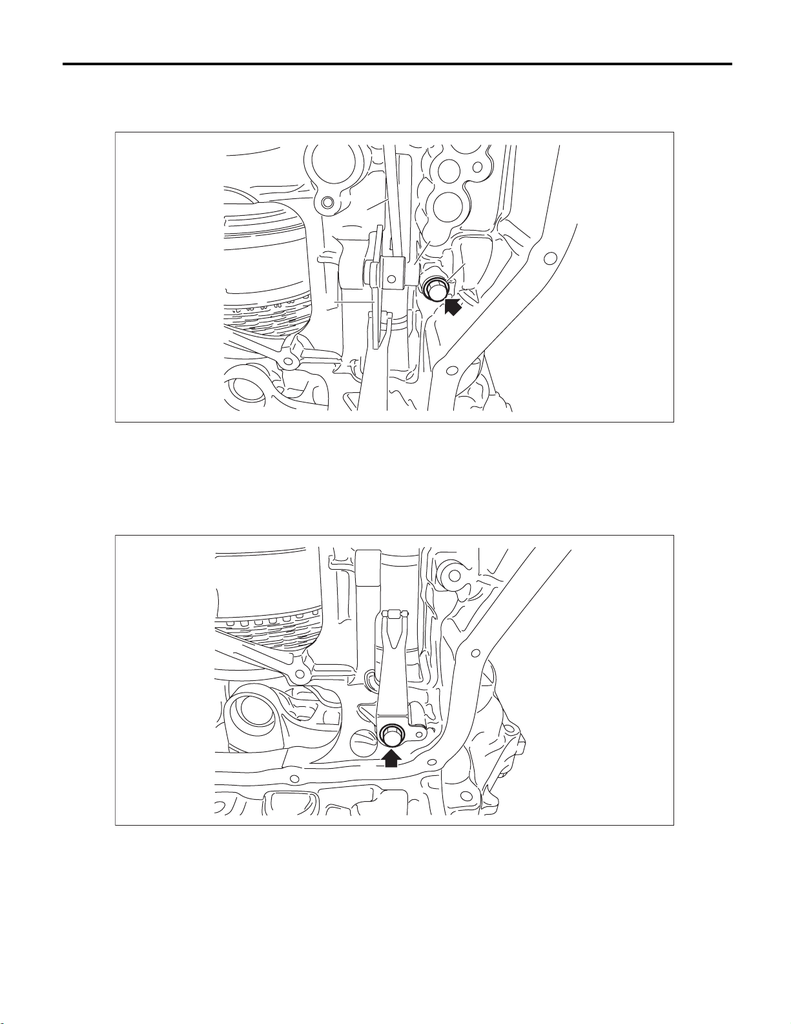

CVT(TR690)-209

Transmission Control Device

CONTINUOUSLY VARIABLE TRANSMISSION

5) Remove the bolt and remove the range select lever, manual plate and parking rod.

NOTE:

Do not damage the lip of oil seal press-fitted in the case.

6) Remove the detent spring.

(A) Bolt

(B) Range select lever

(C) Manual plate

(D) Parking rod

AT-07890

(A)

(B)

(C)

(D)

AT-05276

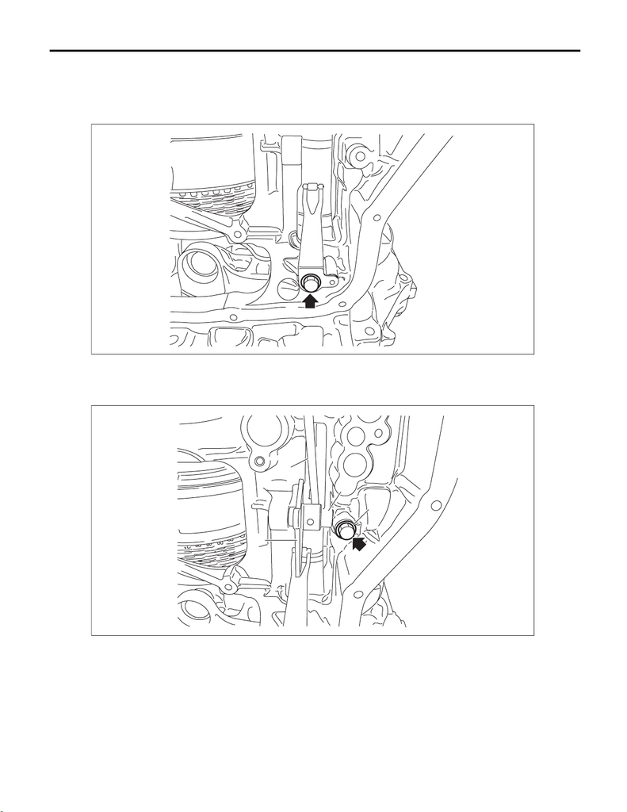

CVT(TR690)-210

Transmission Control Device

CONTINUOUSLY VARIABLE TRANSMISSION

B: INSTALLATION

1) Install the detent spring to the transmission case.

Tightening torque:

7 N·m (0.7 kgf-m, 5.2 ft-lb)

2) Install the manual plate, parking rod, range select lever and bolt.

Tightening torque:

7 N·m (0.7 kgf-m, 5.2 ft-lb)

(A) Bolt

(B) Range select lever

(C) Manual plate

(D) Parking rod

AT-05276

AT-07890

(A)

(B)

(C)

(D)

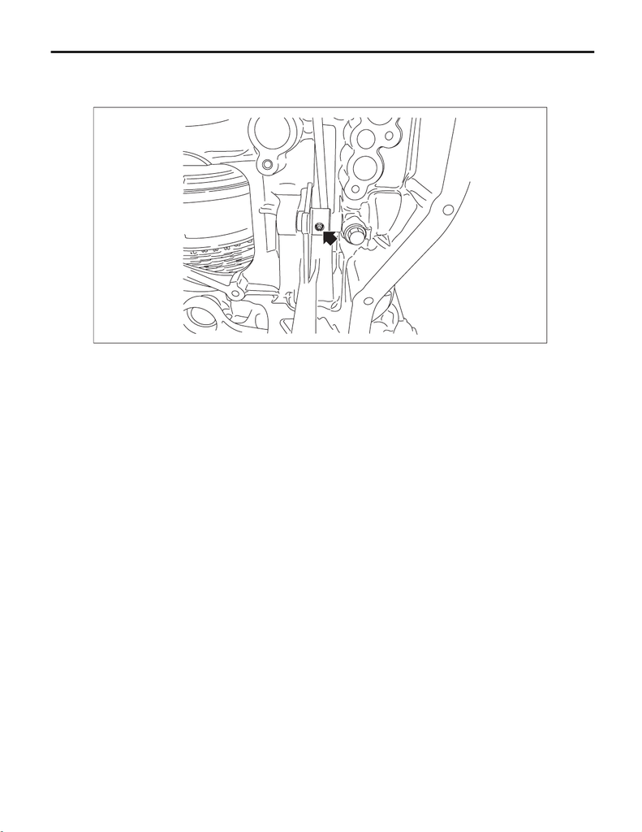

CVT(TR690)-211

Transmission Control Device

CONTINUOUSLY VARIABLE TRANSMISSION

3) Install the spring pin.

NOTE:

Use new spring pin.

4) Install the inhibitor switch. <Ref. to CVT(TR690)-92, Inhibitor Switch.>

5) Adjust the inhibitor switch. <Ref. to CVT(TR690)-92, Inhibitor Switch.>

Body.>

Transmission Assembly.>

C: INSPECTION

Make sure that the manual lever and detent spring are not worn or otherwise damaged.

AT-05274